# R Notebook

```r
library(readr)
DF <- read_csv("Datos Diversos - Sheet1.csv")
```

```
* `` -> ...19
```

```r
DF$`Tiempo de reacción` <- as.integer(DF$`Tiempo de reacción`)
```

- Mediana:

```r
median(DF$`Tiempo de reacción`, na.rm = TRUE)
```

```
[1] 263
```

- Determine Rango, rango intercuartil y desviación estándar de los tiempos de reacción.
  - Rango:

```r
range(DF$`Tiempo de reacción`, na.rm = TRUE)
```

```
[1]    0 1907
```

- Rango intercuartil:

```r
IQR(DF$`Tiempo de reacción`, na.rm = TRUE)
```

```
[1] 64
```

- Desviación estándar:

```r
sd(DF$`Tiempo de reacción`, na.rm = TRUE)
```

```
[1] 89.25297
```

- Uso de Boxplot:

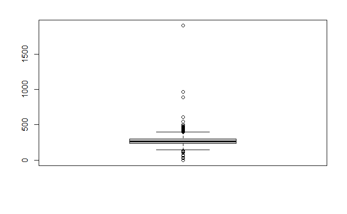

```r
boxplot(DF$`Tiempo de reacción`)
```

- Cantidad de observaciones atípicas en el tiempo de reacción:

```r
length(boxplot.stats(DF$`Tiempo de reacción`)$out)
```

```
[1] 53
```

- Observaciones atípicas:
  - La gran mayoría de valores son de más de 410ms, lo que concidero que demoraron demasiado en responder(cosa que no es normal). Por otro lado, datos muy bajos como 60 o 35 son casi imposibles. El valor 0 considero que fue un error en la toma de la muestra.

```r
boxplot.stats(DF$`Tiempo de reacción`)$out
```

```
 [1]  405  887  503  405    0  412  130  426  472  448  424   25  468  472  542  414  607  455   35  491  425
[22]  428   60  426  436  452  405  420  887  396  399  424  123  436  442  463  421  404  398  120  104  400
[43]  448  487  487  473 1907  422   68  963  446  413  432
```

- Datos entre el primer y tercer cuartil:
  - Los datos entre el primer y tercer cuartil serian el 50% de las observaciones:

```r
quantile(DF$`Tiempo de reacción`, na.rm = TRUE)
```

```
  0%  25%  50%  75% 100%
   0  235  263  299 1907
```

```r
as.integer(nrow(DF)/2)
```

```
[1] 543
```

- Calcular la moda:
  - Usamos la función:

```r
mode <- function(x) {
  return(as.numeric(names(which.max(table(x)))))}
```

```r
mode(DF$`Tiempo de reacción`)
```

```
[1] 250
```

- Histograma:

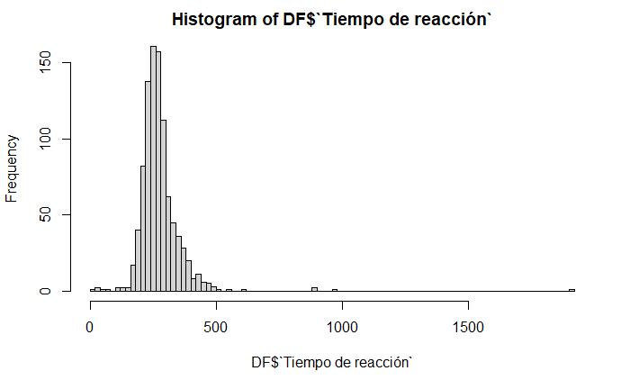

```r
hist(DF$`Tiempo de reacción`, breaks=100)
```

-Es unimodal.